# Project: Investigate a Dataset (TMDb movie data)

By Ahmed Sayed Moustafa

1. Introduction
2. Data Wrangling
3. Exploratory Data Analysis
4. Conclusions
   - Limitations
5. References

**The Dataset Source for this project** is the TMDb movie data (cleaned from original data on Kaggle) and can be found [in the link here.](https://docs.google.com/document/d/e/2PACX-1vTlVmknRRnfy_4eTrjw5hYGaiQim5ctr9naaRd4V9du2B5bxpd8FEH3KtDgp8qVekw7Cj1GLk1IXdZi/pub) This project is a submission for the second project of the Udacity Nanodegree for the EG FWD porgram.

## Section 1. Introduction

#### About the dataset used in this data analysis:

Given information about the dataset:

- This data set contains information about 10,000 movies collected from The Movie Database (TMDb), including user ratings and revenue.
- Certain columns, like ‘cast’ and ‘genres’, contain multiple values separated by pipe (|) characters.
- There are some odd characters in the ‘cast’ column. Don’t worry about cleaning them. You can leave them as is.
- The final two columns ending with “_adj” show the budget and revenue of the associated movie in terms of 2010 dollars, accounting for inflation over time.

#### Preliminary Issues with the given dataset, after checking the CSV file:

- Revenue and Budget have no currency unit, but since the data is about US based movies, I'll assume it's in USD.
- Popularity is gauge of the movie's popularity, but I'm not sure how is it calculated. It's not mentioned anywhere, but I found some [articles about it here](https://help.imdb.com/article/imdb/track-movies-tv/what-s-the-difference-between-the-moviemeter-and-popularity-ranking-on-a-title/G9X2T9KM887YSZYJ?ref_=helpsrall#)[, here](https://community-imdb.sprinklr.com/conversations/imdbcom/how-is-popularity-for-movies-calculated/5f4a79818815453dba7f9288) and [here!](https://www.quora.com/How-does-IMDB-compute-popularity)
- Pipe seperators for some columns
- Several columns such as cast, production companies and genres are grouped in a single entry seperated by "|" so I'll fix that by divining them into seperate columns or unpack them in a seperate dfs, I'll see how it'll go
- Id, IMDB_ID, homepage seem useless is our data analysis, they'll be dropped
- I'll adjust the revneue_adj and budget_adj to 2021, by using [this inflation tool](https://www.inflationtool.com/us-dollar/2010-to-present-value?amount=1000), I found online, I'll adjust it by multiplying by 1.2076
- I'll inspect the data further as a DataFrame and check for further issues

#### The questions I'll look to answer with my analysis:

- Question 1: Is there a specific day and month where movie makers like to release their movies? What's the year with the highest movie releases?
- Question 2: What's the correlation (if any) between the movie's revenue and it's popularity and it's popularity vs the audience vote count?
- Question 3: What's the average movie runtime? What are the top 5 longest movies and how does runtime distribution look like?
- Question 4: What's the highest revenue movie made and is it the same is the most popular movie vs the movie with the highest vote count?
- Question 5: Are we spending more money on making movies over the last years? If yes, are we making more money as well?
- Question 6: What genres of movies are released the most? Which keywords are used in describing movies?
- Question 7: What's the year to recommend to watch the movies released during?
- Question 8: What are the Top 10 highest-revenue movies? By whom were they directed? And what genres do they belong to?
- Question 9: What are the Top 10 production companies in terms of movie releases?
- Question 10: Who are the Top 10 casted actors in the movies?
- Question 11: Who are the Top 10 directors with most movie releases? Who were the directors of the higest revenue movies? Question 11.2: Who were the directors of the most popular movies?

## Section 2. Data Wrangling

```python
#Importing packages/ modules used in this analysis
import pandas as pd
import numpy as np
import matplotlib.pyplot as plt
plt.rcParams['figure.dpi'] = 150
plt.style.use('fivethirtyeight')
import matplotlib as mpl
from matplotlib import cm
import seaborn as sns
%matplotlib inline
from wordcloud import WordCloud
import squarify
```

```python
#Import the CSV file as a Pandas dataframe
df = pd.read_csv('tmdb-movies.csv', encoding='utf-8', parse_dates=True)
```

### A. General Properties

```python
# Check the dataframe head
df.head(2)
```

|  | id | imdb_id | popularity | budget | revenue | original_title | cast | homepage | director | tagline | ... | overview | runtime | genres | production_companies | release_date | vote_count | vote_average | release_year | budget_adj | revenue_adj |
| --- | --- | --- | --- | --- | --- | --- | --- | --- | --- | --- | --- | --- | --- | --- | --- | --- | --- | --- | --- | --- | --- |
| 0 | 135397 | tt0369610 | 32.985763 | 150000000 | 1513528810 | Jurassic World | Chris Pratt\|Bryce Dallas Howard\|Irrfan Khan\|Vi... | http://www.jurassicworld.com/ | Colin Trevorrow | The park is open. | ... | Twenty-two years after the events of Jurassic ... | 124 | Action\|Adventure\|Science Fiction\|Thriller | Universal Studios\|Amblin Entertainment\|Legenda... | 6/9/15 | 5562 | 6.5 | 2015 | 1.379999e+08 | 1.392446e+09 |
| 1 | 76341 | tt1392190 | 28.419936 | 150000000 | 378436354 | Mad Max: Fury Road | Tom Hardy\|Charlize Theron\|Hugh Keays-Byrne\|Nic... | http://www.madmaxmovie.com/ | George Miller | What a Lovely Day. | ... | An apocalyptic story set in the furthest reach... | 120 | Action\|Adventure\|Science Fiction\|Thriller | Village Roadshow Pictures\|Kennedy Miller Produ... | 5/13/15 | 6185 | 7.1 | 2015 | 1.379999e+08 | 3.481613e+08 |

2 rows × 21 columns

```python
# Check null values and data types
df.info()
```

```
<class 'pandas.core.frame.DataFrame'>
RangeIndex: 10866 entries, 0 to 10865
Data columns (total 21 columns):
 #   Column                Non-Null Count  Dtype
---  ------                --------------  -----
 0   id                    10866 non-null  int64
 1   imdb_id               10856 non-null  object
 2   popularity            10866 non-null  float64
 3   budget                10866 non-null  int64
 4   revenue               10866 non-null  int64
 5   original_title        10866 non-null  object
 6   cast                  10790 non-null  object
 7   homepage              2936 non-null   object
 8   director              10822 non-null  object
 9   tagline               8042 non-null   object
 10  keywords              9373 non-null   object
 11  overview              10862 non-null  object
 12  runtime               10866 non-null  int64
 13  genres                10843 non-null  object
 14  production_companies  9836 non-null   object
 15  release_date          10866 non-null  object
 16  vote_count            10866 non-null  int64
 17  vote_average          10866 non-null  float64
 18  release_year          10866 non-null  int64
 19  budget_adj            10866 non-null  float64
 20  revenue_adj           10866 non-null  float64
dtypes: float64(4), int64(6), object(11)
memory usage: 1.7+ MB
```

```python
# Check shape and the column names of the data frame
df.shape, df.columns
```

```
((10866, 21),
 Index(['id', 'imdb_id', 'popularity', 'budget', 'revenue', 'original_title',
        'cast', 'homepage', 'director', 'tagline', 'keywords', 'overview',
        'runtime', 'genres', 'production_companies', 'release_date',
        'vote_count', 'vote_average', 'release_year', 'budget_adj',
        'revenue_adj'],
       dtype='object'))
```

```python
# Check the summary statistics for our columns
df.describe()
```

|  | id | popularity | budget | revenue | runtime | vote_count | vote_average | release_year | budget_adj | revenue_adj |
| --- | --- | --- | --- | --- | --- | --- | --- | --- | --- | --- |
| count | 10866.000000 | 10866.000000 | 1.086600e+04 | 1.086600e+04 | 10866.000000 | 10866.000000 | 10866.000000 | 10866.000000 | 1.086600e+04 | 1.086600e+04 |
| mean | 66064.177434 | 0.646441 | 1.462570e+07 | 3.982332e+07 | 102.070863 | 217.389748 | 5.974922 | 2001.322658 | 1.755104e+07 | 5.136436e+07 |
| std | 92130.136561 | 1.000185 | 3.091321e+07 | 1.170035e+08 | 31.381405 | 575.619058 | 0.935142 | 12.812941 | 3.430616e+07 | 1.446325e+08 |
| min | 5.000000 | 0.000065 | 0.000000e+00 | 0.000000e+00 | 0.000000 | 10.000000 | 1.500000 | 1960.000000 | 0.000000e+00 | 0.000000e+00 |
| 25% | 10596.250000 | 0.207583 | 0.000000e+00 | 0.000000e+00 | 90.000000 | 17.000000 | 5.400000 | 1995.000000 | 0.000000e+00 | 0.000000e+00 |
| 50% | 20669.000000 | 0.383856 | 0.000000e+00 | 0.000000e+00 | 99.000000 | 38.000000 | 6.000000 | 2006.000000 | 0.000000e+00 | 0.000000e+00 |
| 75% | 75610.000000 | 0.713817 | 1.500000e+07 | 2.400000e+07 | 111.000000 | 145.750000 | 6.600000 | 2011.000000 | 2.085325e+07 | 3.369710e+07 |
| max | 417859.000000 | 32.985763 | 4.250000e+08 | 2.781506e+09 | 900.000000 | 9767.000000 | 9.200000 | 2015.000000 | 4.250000e+08 | 2.827124e+09 |

- Looking the df stats we can see that there are zero-values in the budget, budget_adj, revenue and revenue_adj columns, so I need to fix that.
- Revenue_adj and buget_adj are floats and they will be changed to int64 to match the budget and revenue original columns
- The runtime column has a a very strange maximum of 900, seems strange, I'll check that as well as the minimum of 3. Let's not forget the zero value(s) there as well
- The popularity's 75% percentile is less than 1, but the max is 32.98, hmm that's a very big gap. It may be an outlier

```python
# Checking the keywords column, I might try making a word cloud with all the repeated keywords
df.keywords.head(2)
```

```
0    monster|dna|tyrannosaurus rex|velociraptor|island
1     future|chase|post-apocalyptic|dystopia|australia
Name: keywords, dtype: object
```

#### After looking at the dataframe of the dataset of movie, I'll perform the following steps to prepare the data for analysis

- remove all NaN containing rows
- remove all duplicate entries
- remove any data that doesn't conform to normal ranges, i.e. out of range years and zero values for example, runtime, budget, revenue columns
- fix the release date so it's datetime64
- divide cast, keywords, genres and production_companies columns into seperate ones so each is in a seperate dataframe seperated into columns

### B. Data Cleaning Process

- **B.1** Removing unused columns from the dataframe

```python
#let's start by dropping the unused columns in the dataset, I'll create a new clean dataframe call it df
df.drop(columns=['id', 'imdb_id','homepage','tagline', 'overview'], inplace=True)
```

```python
#check for missing values
df.isnull().sum()
```

```
popularity                 0
budget                     0
revenue                    0
original_title             0
cast                      76
director                  44
keywords                1493
runtime                    0
genres                    23
production_companies    1030
release_date               0
vote_count                 0
vote_average               0
release_year               0
budget_adj                 0
revenue_adj                0
dtype: int64
```

- **B.2** Cleaning NaN values in dataframe

```python
#drop NaN values
df = df.dropna(how='any')
```

```python
#check again
df.isnull().sum()
df.isnull().sum().any() #False if all cleared
```

```
False
```

- **B.3** Cleaning duplicates in dataframe

```python
#check for duplicates
df.duplicated().value_counts()
```

```
False    8666
True        1
dtype: int64
```

```python
#clear the duplicate entry
df.drop_duplicates(inplace=True)
```

```python
#check the date shape
df.shape
```

```
(8666, 16)
```

```python
#check if everything is clear
df.duplicated().sum()
```

```
0
```

```python
#Inspect the data of each column closely, to check for further cleaning and wrangling, I'll check one by one and comment them
#out as I move through the columns:

#column name #short description
#df.id #numeric int64
#df.imdb_id #string format as ("tt" + int(0000000))
#df.popularity  #a specific scale for the movie's popularity, IDEA! Benchmark all the movies against the most popular?
#df.budget #I might not use this at all
#df.revenue #I might not use this at all
```

```python
# checking the year range we're working with in this dataset
df.release_year.max(), df.release_year.min()
```

```
(2015, 1960)
```

- **B.4** Adjusting the revenue_adj and budget_adj by multiplying it with the inflation factor of 2021 using the value from the [inflation calculator](https://www.inflationtool.com/us-dollar/2010-to-present-value) Then changing the dtype to int64.

```python
# First I'll create a variable for 2021 inflation adjustment
inflation_adj_2021 = 1.2076
# adjust the revenue_adj and budget_adj columns
df.revenue_adj = inflation_adj_2021 * df.revenue_adj
df.budget_adj = inflation_adj_2021 * df.budget_adj
```

```python
# Now I'll change the dtype of revenue_adj and budget_adj columsn to int
df.revenue_adj = df.revenue_adj.astype(np.int64)
df.budget_adj = df.budget_adj.astype(np.int64)
```

```python
# Check that it has been changed successfully
#df.info()    #I'll comment it out for now
```

*Before moving forward with any specific adjustments for the dataframe, I'm going to create subset i.e mini dataframes to work and analyse to keep the original dataframe intact and in case I need to recall it later on.*</br>

The following will be created:

- df_money
- df_cast
- df_genres
- df_keywords
- df_prod_companies
- df_directors
- df_movie_runtime
- df_expanded

Let's move in then!

- **B.5** Cleaning the Runtime Column (Dropping Zero-Value Rows)

```python
# Check df.runtime to check for outliers or wrong entries or zeroes
(df.runtime == 0).sum()
```

```
7
```

*First problem is that we have a couple of zero runtime values, we'll have to drop those.*

```python
df.runtime.describe()
```

```
count    8666.000000
mean      103.815140
std        26.207186
min         0.000000
25%        91.000000
50%       100.000000
75%       113.000000
max       705.000000
Name: runtime, dtype: float64
```

*Second issue is there is a min of 3 minutes and maximum of 705, that doesn't seem right, luckily those values have zero budget and revenue and will be removed later on.*

```python
#dropping the rows with the zero value
df = df[df.runtime != 0]
```

```python
# Check for removal of zero values
df[df.runtime == 0]
#OR
#(df.runtime == 0).sum()
```

|  | popularity | budget | revenue | original_title | cast | director | keywords | runtime | genres | production_companies | release_date | vote_count | vote_average | release_year | budget_adj | revenue_adj |
| --- | --- | --- | --- | --- | --- | --- | --- | --- | --- | --- | --- | --- | --- | --- | --- | --- |

```python
# Let's take a look at the runtime stats again
df.runtime.describe()
```

```
count    8659.000000
mean      103.899065
std        26.050934
min         3.000000
25%        91.000000
50%       100.000000
75%       113.000000
max       705.000000
Name: runtime, dtype: float64
```

*I'll adjust the bounds for the runtime by checking the outliers range*</br>

> High = (Q3) + 1.5 IQ<R</br> Low = (Q1) – 1.5 IQR </br>Resource: https://www.statisticshowto.com/statistics-basics/find-outliers/

```python
# Check the outliers with the formula above
High = 113.0 + 1.5*(100.00)
Low = 91.00 - 1.5*(100.00)
Low, High
# Ok since we don't have negative runtime values, I'll disregard the low for the outliers and just use the high for further checking
```

```
(-59.0, 263.0)
```

```python
# Check main df for values above 263
df[df.runtime >= 263].head(2)
# Ok so some of these are not movies in the sense they weren't in the theatre but a TV mini series for example 'Band of Brothers' and 'life'
```

|  | popularity | budget | revenue | original_title | cast | director | keywords | runtime | genres | production_companies | release_date | vote_count | vote_average | release_year | budget_adj | revenue_adj |
| --- | --- | --- | --- | --- | --- | --- | --- | --- | --- | --- | --- | --- | --- | --- | --- | --- |
| 1235 | 0.093377 | 0 | 0 | Klondike | Richard Madden\|Abbie Cornish\|Sam Shepard\|Tim R... | Simon Cellan Jones | gold rush\|tv mini-series | 285 | Drama\|History | Scott Free Productions\|Discovery Channel\|E1 En... | 1/20/14 | 17 | 6.7 | 2014 | 0 | 0 |
| 1865 | 0.102223 | 0 | 0 | Life | David Attenborough\|Oprah Winfrey | Martha Holmes\|Simon Blakeney\|Stephen Lyle | plants\|animal species\|biology\|wildlife\|ecology | 500 | Documentary | British Broadcasting Corporation (BBC) | 12/14/09 | 24 | 7.0 | 2009 | 0 | 0 |

```python
# Let's take a look at the 3 minute runtime, hmm seems strange!
df[df.runtime <= 3]
```

|  | popularity | budget | revenue | original_title | cast | director | keywords | runtime | genres | production_companies | release_date | vote_count | vote_average | release_year | budget_adj | revenue_adj |
| --- | --- | --- | --- | --- | --- | --- | --- | --- | --- | --- | --- | --- | --- | --- | --- | --- |
| 1112 | 0.202776 | 0 | 0 | Batman: Strange Days | Kevin Conroy\|Brian George\|Tara Strong | Bruce Timm | dc comics\|superhero\|based on comic book\|noir\|p... | 3 | Action\|Animation | DC Comics | 4/9/14 | 20 | 7.6 | 2014 | 0 | 0 |
| 2830 | 0.254157 | 0 | 0 | Shrek in the Swamp Karaoke Dance Party | Mike Myers\|Eddie Murphy | Vicky Jenson\|Andrew Adamson | song\|shrek\|woman director | 3 | Animation\|Comedy\|Music | DreamWorks Animation | 1/1/01 | 12 | 5.4 | 2001 | 0 | 0 |
| 3298 | 0.152615 | 0 | 0 | MamÃ¡ | Victoria Harris\|Irma Monroig\|Berta Ros | Andy Muschietti | possessed | 3 | Horror | Toma 78 | 10/7/08 | 11 | 6.0 | 2008 | 0 | 0 |
| 8706 | 0.811101 | 0 | 0 | For the Birds | Ralph Eggleston | Ralph Eggleston | bird\|pixar animated short\|clique\|awkward appea... | 3 | Animation\|Comedy\|Family | Pixar Animation Studios | 11/1/00 | 247 | 7.7 | 2000 | 0 | 0 |

Note: *So I googled the movies 'For the Birds', 'Shred in the Swamp Karaoke Dance Party' and 'Batman: Strange Days' in that subset and they do have a runtime https://en.wikipedia.org/wiki/For_the_Birds_(film), https://en.wikipedia.org/wiki/Batman:_Strange_Dayswhich which around 3 min so that seems right, however, this one https://en.wikipedia.org/wiki/Mama_(2013_film) Mama, seems to be 100 minutes of runtime, so I'll drop that specific value from the main dataframe as well.*

```python
# Drop the wrong value of runtime
df = df[df.index != 3298]
```

```python
# Check it's removed, should yeild an empty df
df[df.original_title == 'MamÃ¡']
```

|  | popularity | budget | revenue | original_title | cast | director | keywords | runtime | genres | production_companies | release_date | vote_count | vote_average | release_year | budget_adj | revenue_adj |
| --- | --- | --- | --- | --- | --- | --- | --- | --- | --- | --- | --- | --- | --- | --- | --- | --- |

```python
# I'll subset the original title, release year and runtime into a seperate mini df to remove the outliers from
df_movie_runtime = df[['release_year','original_title','runtime']]
df_movie_runtime.head(1)
```

|  | release_year | original_title | runtime |
| --- | --- | --- | --- |
| 0 | 2015 | Jurassic World | 124 |

```python
# Drop the values above 263 (higer range of the IQR)
df_movie_runtime = df_movie_runtime[df_movie_runtime.runtime <= 263.00]
```

*Note: Some of these are not movies in the sense they weren't in the theatre but a TV mini series for example 'Band of Brothers' and 'life'*

```python
# Let's check if he have anything else above 263
(df_movie_runtime.runtime > 263.00).sum()
```

```
0
```

- **B.6** Cleaning the Revenue and Budget Columns

```python
# Check df.budget to check for outliers or wrong entries or zeroes,
# if revenue values are zero I'll assume the movie didn't make money so I'll leave those and just remove the budget
(df.budget_adj == 0).sum(), (df.revenue_adj == 0).sum()
```

```
(3933, 4122)
```

```python
#let's take a closer look
df[(df.revenue_adj == 0) & (df.budget_adj != 0)].head(2)
```

|  | popularity | budget | revenue | original_title | cast | director | keywords | runtime | genres | production_companies | release_date | vote_count | vote_average | release_year | budget_adj | revenue_adj |
| --- | --- | --- | --- | --- | --- | --- | --- | --- | --- | --- | --- | --- | --- | --- | --- | --- |
| 48 | 2.932340 | 30000000 | 0 | Wild Card | Jason Statham\|Michael Angarano\|Milo Ventimigli... | Simon West | gambling\|bodyguard\|remake | 92 | Thriller\|Crime\|Drama | Current Entertainment\|Lionsgate\|Sierra / Affin... | 1/14/15 | 481 | 5.3 | 2015 | 33329745 | 0 |
| 67 | 2.331636 | 20000000 | 0 | Survivor | Pierce Brosnan\|Milla Jovovich\|Dylan McDermott\|... | James McTeigue | new year's eve\|fire\|showdown\|terrorist\|embassy | 96 | Crime\|Thriller\|Action | Nu Image Films\|Winkler Films\|Millennium Films\|... | 5/21/15 | 280 | 5.4 | 2015 | 22219830 | 0 |

Well that's not good news, the revenue is still zero for many of these values. So I checked a random movie Survivor and the budget number is on point but the revenue is zero which is off and it says on the wikipedia page it made in box office $3,839,100 so I'll drop them.

```python
# Removing all zero values from revenue_adj in the main df
#df = df[df.revenue_adj != 0]
```

```python
# Removing all zero values from budget_adj  in the main df
#df = df[df.budget_adj != 0]
```

```python
# Let me make a new dataframe to keep the main df intact
monetary_columns = ['original_title','popularity','vote_average','vote_count','production_companies','release_year','budget_adj','revenue_adj','budget','revenue']
df_money = df[monetary_columns]
df_money.head(2)
```

|  | original_title | popularity | vote_average | vote_count | production_companies | release_year | budget_adj | revenue_adj | budget | revenue |
| --- | --- | --- | --- | --- | --- | --- | --- | --- | --- | --- |
| 0 | Jurassic World | 32.985763 | 6.5 | 5562 | Universal Studios\|Amblin Entertainment\|Legenda... | 2015 | 166648726 | 1681517659 | 150000000 | 1513528810 |
| 1 | Mad Max: Fury Road | 28.419936 | 7.1 | 6185 | Village Roadshow Pictures\|Kennedy Miller Produ... | 2015 | 166648726 | 420439576 | 150000000 | 378436354 |

```python
# Check for rows with zero values, I chose revenue because it has more zero values than budget, and I'll double check again after this is done
to_remove_budget = df_money.revenue[df_money.revenue == 0]
to_remove_budget.index.values.shape[0]
```

```
4122
```

Creating a new df_money so I can remove the zero-value rows from it

```python
# Removing zero value row i.e keeping the ones with actual value
df_money = df_money[df_money.revenue_adj != 0]
df_money = df_money[df_money.budget_adj != 0]
```

```python
# Check for removal and cross check for budget zero values
(df_money.revenue == 0).sum(), (df_money.budget == 0).sum() #both should read zeros
```

```
(0, 0)
```

```python
# check df_money
df_money.info()
```

```
<class 'pandas.core.frame.DataFrame'>
Int64Index: 3677 entries, 0 to 10848
Data columns (total 10 columns):
 #   Column                Non-Null Count  Dtype
---  ------                --------------  -----
 0   original_title        3677 non-null   object
 1   popularity            3677 non-null   float64
 2   vote_average          3677 non-null   float64
 3   vote_count            3677 non-null   int64
 4   production_companies  3677 non-null   object
 5   release_year          3677 non-null   int64
 6   budget_adj            3677 non-null   int64
 7   revenue_adj           3677 non-null   int64
 8   budget                3677 non-null   int64
 9   revenue               3677 non-null   int64
dtypes: float64(2), int64(6), object(2)
memory usage: 316.0+ KB
```

*df_money* df containing budget, revenue and names of movies

- **B.7** Supressing the scientific notation to make numbers more readable

```python
# Adjusting the display for numbers so they suppress the scientific notation
pd.options.display.float_format = '{:.2f}'.format
```

```python
#df.vote_average.describe(),df.vote_count.describe()
```

- **B.8** Change the release_date to datetime64

```python
#Change the release data to the appropriate data type
df['release_date'] = pd.to_datetime(df.release_date)
```

- Most of the dates seems ok but there is an issue with the dates under year 1969, Python to_datetime reads it as year 2XXX for example 1966 will be 2066. https://stackoverflow.com/questions/37766353/pandas-to-datetime-parsing-wrong-year
- I decided to strip the month and day in new columns since the year is already available in the column release year and I'll drop it from our df as well.

```python
#Create new columns for release month and day
df['release_month'] = df['release_date'].dt.month_name()
df['release_day'] = df['release_date'].dt.day_name()
```

### C. Create Functions and the Subset dataframes

#### C.1 Create the function for splitting the main df columns into seperate dataframes and outputting a dataframe with values in seperate columns

```python
# Define a function to seperate and rename columns into new subsetted dataframes
def cols_make(dfcolumn):
    """
    Expands a single column in a dataframe with a delimiter, in this case it's pipe '|'
    Args:
        (dfcolumn) The dataframe column which you want to split values in a single column into a new dataframe with
         multiple columns
    Returns:
        A dataframe of seperated columns of the values, with renames column names
    """
    return dfcolumn.str[0:].str.split('|',expand = True)

#run the function on the desired columns
df_cast = cols_make(df.cast).rename(columns = lambda x: f"cast_{x+1}")
df_genres = cols_make(df.genres).rename(columns = lambda x: f"genres_{x+1}")
df_keywords = cols_make(df.keywords).rename(columns = lambda x: f"keywords_{x+1}")
df_prod_companies = cols_make(df.production_companies).rename(columns = lambda x: f"prod_comp_{x+1}")
df_director = cols_make(df.director).rename(columns = lambda x: f"director_{x+1}")
```

```python
#Check the df were created
df_cast.head(1), df_genres.head(1), df_keywords.head(1), df_prod_companies.head(1), df_director.head(1)
```

```
(        cast_1               cast_2       cast_3             cast_4  \
 0  Chris Pratt  Bryce Dallas Howard  Irrfan Khan  Vincent D'Onofrio

           cast_5
 0  Nick Robinson  ,
   genres_1   genres_2         genres_3  genres_4 genres_5
 0   Action  Adventure  Science Fiction  Thriller     None,
   keywords_1 keywords_2         keywords_3    keywords_4 keywords_5
 0    monster        dna  tyrannosaurus rex  velociraptor     island,
          prod_comp_1           prod_comp_2         prod_comp_3  \
 0  Universal Studios  Amblin Entertainment  Legendary Pictures

                prod_comp_4 prod_comp_5
 0  Fuji Television Network      Dentsu  ,
         director_1 director_2 director_3 director_4 director_5 director_6  \
 0  Colin Trevorrow       None       None       None       None       None

   director_7 director_8 director_9 director_10  ... director_27 director_28  \
 0       None       None       None        None  ...        None        None

   director_29 director_30 director_31 director_32 director_33 director_34  \
 0        None        None        None        None        None        None

   director_35 director_36
 0        None        None

 [1 rows x 36 columns])
```

#### C.2 The function for melting and counting the values of the cast, genre, keyword and production company and outputing a pd.Series

```python
# Define a function to melt all columns, count each value occurence and return a pd.Series
def col_stacker(df):
    """
    Creates a a single-column series from a given dataframes with columns, counts it's values and sorts it
    Args:
        (df) The dataframe which you want to combine all columns into a single column
    Returns:
        A single column of values, counted and sorted as a pd.series
    """
    return df.melt()['value'].value_counts(sort=True)

#run the function on the desired columns
actors_series = col_stacker(df_cast)
genres_series = col_stacker(df_genres)
keywords_series = col_stacker(df_keywords)
prod_comp_series = col_stacker(df_prod_companies)
directors_series = col_stacker(df_director)
```

```python
# Check if everything looks ok
actors_series.head(1), genres_series.head(1), keywords_series.head(1), prod_comp_series.head(1), directors_series.head(1)
```

```
(Robert De Niro    68
 Name: value, dtype: int64,
 Drama    3932
 Name: value, dtype: int64,
 independent film    339
 Name: value, dtype: int64,
 Warner Bros.    495
 Name: value, dtype: int64,
 Woody Allen    41
 Name: value, dtype: int64)
```

#### C.3 Create some new dataframes for further analysis

- df_director
- df_expanded

```python
#df_direct_col = df.director['all_directors'] = df_director[df_director.columns[0:]].apply(lambda x:','.join(x.dropna().astype(str)), axis=1)
#df_director
df.director.replace('|','', regex=True, inplace=True)
df.director.head(2)
```

```
0    Colin Trevorrow
1      George Miller
Name: director, dtype: object
```

```python
# I'll create a new expanded view dataframe for further analysis
columns_to_add = ['original_title','popularity','release_year', 'revenue_adj', 'director']
df_expanded = df[columns_to_add].join(df_cast)
df_expanded = df_expanded.join(df_genres)
```

```python
df_expanded.head(1)
```

|  | original_title | popularity | release_year | revenue_adj | director | cast_1 | cast_2 | cast_3 | cast_4 | cast_5 | genres_1 | genres_2 | genres_3 | genres_4 | genres_5 |
| --- | --- | --- | --- | --- | --- | --- | --- | --- | --- | --- | --- | --- | --- | --- | --- |
| 0 | Jurassic World | 32.99 | 2015 | 1681517659 | Colin Trevorrow | Chris Pratt | Bryce Dallas Howard | Irrfan Khan | Vincent D'Onofrio | Nick Robinson | Action | Adventure | Science Fiction | Thriller | None |

```python
# Average popularity rating accross the years
df[['release_year','popularity']].groupby('release_year').mean().sort_values('popularity', ascending=False).head(2)
```

| release_year | popularity |
| --- | --- |
| 2015 | 1.36 |
| 2014 | 1.10 |

```python
#check that the columns have been removed/ What's this?
# df.columns
```

## Section 3. Exploratory Data Analysis

- First let's take a look at the overall data we have and make some deductions about it

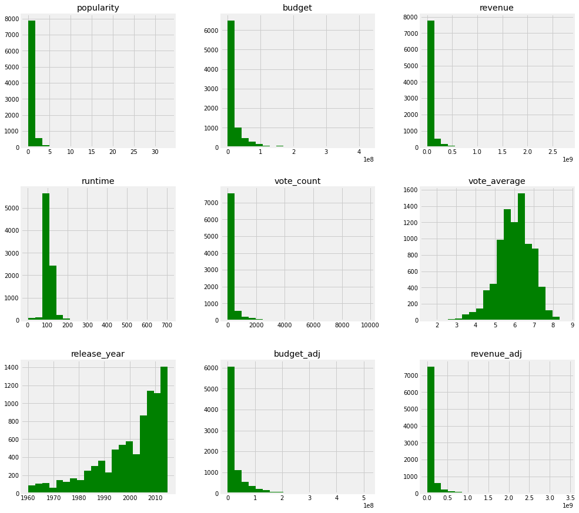

```python
# drop the release date fixed since there is a issue with the year and I don't need it since we have a release year histogram
df.drop(['release_date'], axis=1).hist(bins=20, color='g', figsize=(15,15));
```

#### Initial Observations:

- The runtime distribution is slight right skewed, and it indicates that most of the movies runtime lies around the 100 min marker
- The vote average distribution seems to be a nice bell shape indicative of a normal distribtion, which makes sense since we're taking into account votes of many people with many preferences in movies
- The release year seems to be left skewed, indicating that more movies are being released over the last decade, we'll check the numbers soon to confirm!

Let's look at some interesting questions and their answers.

*Stay Tuned!*

**Question 1: Is there a specific day and month where movie makers like to release their movies? What's the year with the highest movie releases?**

```python
# most popular release month and day of the week, that should be INTERESTING!
df['release_year'].mode()[0], df['release_month'].mode()[0], df['release_day'].mode()[0]
```

```
(2014, 'September', 'Friday')
```

```python
df.release_day.value_counts()
```

```
Friday       3538
Thursday     1406
Wednesday    1239
Tuesday       901
Saturday      576
Sunday        505
Monday        493
Name: release_day, dtype: int64
```

#### - Let's plot some bars to see the results visually

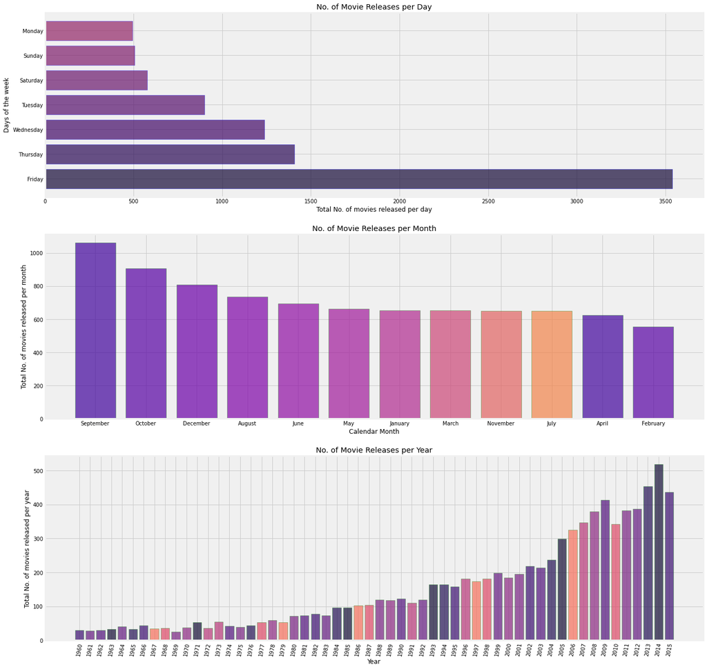

```python
#Let's plot these 3 barplots to see how they'll look like.

#1 Setting the data for the bar graphs
days_rel = df.release_day.value_counts()
months_rel = df.release_month.value_counts()
years_rel = df.release_year.value_counts()

#2 Set 3 subplots and the figure size
fig, (ax1, ax2, ax3) = plt.subplots(3,1)
fig.set_size_inches(20,22)

#3 Adjust the colors to make the plot sparkle
cmap1 = mpl.cm.inferno
cmap2 = mpl.cm.plasma
cmap3 = mpl.cm.magma

colors1 = cmap1([0.1, 0.15, 0.2, 0.25, 0.3, 0.35, 0.4, 0.5, 0.6, 0.7])
colors2 = cmap2([0.1, 0.15, 0.2, 0.25, 0.3, 0.35, 0.4, 0.5, 0.6, 0.7])
colors3 = cmap3([0.1, 0.15, 0.2, 0.25, 0.3, 0.35, 0.4, 0.5, 0.6, 0.7])

#4 plotting the bars
ax1.barh(days_rel.index, days_rel.values, alpha =0.7, color=colors1, edgecolor='blue')
ax2.bar(months_rel.index, months_rel.values, alpha =0.7, color=colors2, edgecolor='green')
ax3.bar(years_rel.index, years_rel.values, alpha =0.7, color=colors3, edgecolor='green')

#figure titles
ax1.set_title('No. of Movie Releases per Day')
ax2.set_title('No. of Movie Releases per Month')
ax3.set_title('No. of Movie Releases per Year')

#figure axis names
ax1.set_xlabel('Total No. of movies released per day')
ax1.set_ylabel('Days of the week')

ax2.set_xlabel('Calendar Month')
ax2.set_ylabel('Total No. of movies released per month')

ax3.set_xlabel('Year')
ax3.set_ylabel('Total No. of movies released per year')

#adjust the xtick for the years barplot
ax3.set_xticks(years_rel.index)
ax3.tick_params(axis='x', labelrotation=80)
```

> **Observation/ Commentary:**
- The most popular day to release movie was Friday. The most popular month is September and most popular year is 2014.

**Question 2: What's the correlation (if any) between the movie's revenue and it's popularity and it's popularity vs the audience vote count?**

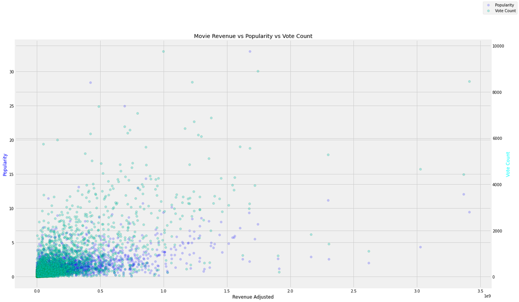

```python
#Let's plot a scatter plot for popularity vs revenue and vs audience vote count
y = df_money.popularity
x = df_money.revenue_adj
z = df_money.vote_count

# Set subplots and the figure size
fig, ax1 = plt.subplots(figsize=(20, 12))

#plotting the scatter_1
ax1.scatter(x, y, alpha =0.2, color='b', edgecolor='blue')

#scattee_2
ax2 = ax1.twinx()
ax2.scatter(x, z, alpha =0.3, color='c', edgecolor='green')

#Set label for X, Y axis for plots
ax1.set_ylabel("Popularity", color="blue")
ax2.set_ylabel("Vote Count", color="cyan")
ax1.set_xlabel("Revenue Adjusted", color="black")

#figure title
ax1.set_title('Movie Revenue vs Popularity vs Vote Count')

fig.legend(["Popularity", "Vote Count"]);
#ax2.set_title('Popularity vs. Vote Count');
```

> **Observation/ Commentary:** There is a slight positive correlation between revenue and vote count vs popularity. Popular movies made higher revenue.

**Question 3: What's the average movie runtime? What are the top 5 longest movies and how does runtime distribution look like?**

```python
#First let's take a look at the runtime stats
df_movie_runtime.runtime.describe()
```

```
count   8641.00
mean     103.34
std       22.12
min        3.00
25%       91.00
50%      100.00
75%      113.00
max      254.00
Name: runtime, dtype: float64
```

> Ok so the average running time is around 103 minutes, and the 75% percentile is at 113 minutes, this makes sense, since most movies a runtime of 90-120 minutes, we'll see the histogram soon to visually check this. The minimum is bizarre yet true, 3 movies in our dataset have a running time of around 3 minutes.

*Let's take a look at the top **5** Movies with longest Runtime*

```python
# Let's group the release year and runtime and check the average
df_movie_runtime.groupby('original_title').mean().sort_values('runtime', ascending=False).head(5)
```

| original_title | release_year | runtime |
| --- | --- | --- |
| Gettysburg | 1993.00 | 254.00 |
| Rose Red | 2002.00 | 254.00 |
| Cleopatra | 1963.00 | 248.00 |
| Frank Herbert's Children of Dune | 2003.00 | 248.00 |
| Kill Bill: The Whole Bloody Affair | 2011.00 | 247.00 |

- Movie Runtime Distribution

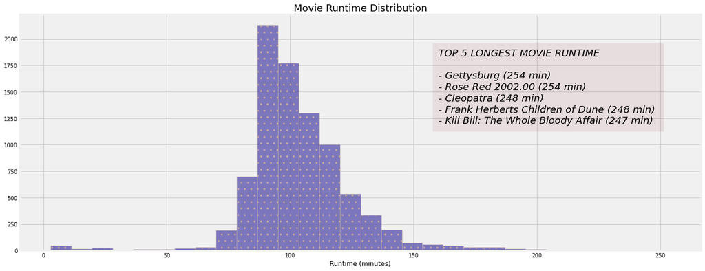

```python
x = df_movie_runtime.runtime

# Set 1 subplot and the figure size
fig, ax = plt.subplots(figsize=(20, 8))

#get the required color pallete
cmap = mpl.cm.twilight

#plotting the scatter plots
ax.hist(x, bins=30, alpha =0.8, color=cmap(0.3), edgecolor=cmap(0.9), hatch=".")

ax.text(160,1200,'TOP 5 LONGEST MOVIE RUNTIME \n \n- Gettysburg (254 min) \n- Rose Red 2002.00 (254 min) \n- Cleopatra (248 min) \n- Frank Herberts Children of Dune (248 min) \n- Kill Bill: The Whole Bloody Affair (247 min)', fontsize='18', style='italic',
        bbox={'facecolor':cmap(0.7), 'alpha': 0.1, 'pad': 10})

#figure title
ax.set_xlabel('Runtime (minutes)')
ax.set_title ('Movie Runtime Distribution', fontsize=18);
```

> **Observation/ Commentary:** The distribution of the runtime seems to be skewed to the right, around 50% of the movies have a runtime of 100 minute, although 75% of the movies had a running time of 113 minutes.

**Question 4: What's the highest revenue movie made and is it the same is the most popular movie vs the movie with the highest vote count?**

```python
# Check the movie with the highest revenue
df[df.revenue_adj == df.revenue_adj.max()][['original_title','release_year']]
```

|  | original_title | release_year |
| --- | --- | --- |
| 1386 | Avatar | 2009 |

```python
# Check the movie with the highest popularity
df[df.popularity == df.popularity.max()][['original_title','release_year']]
```

|  | original_title | release_year |
| --- | --- | --- |
| 0 | Jurassic World | 2015 |

```python
# Check the movie with the highest vote count
df[df.vote_count == df.vote_count.max()][['original_title','release_year']]
```

|  | original_title | release_year |
| --- | --- | --- |
| 1919 | Inception | 2010 |

> **Observation/ Commentary:** The movie with the highest revenue is "2009's Avatar" but the one with highest popularity is "2015's Jurassic World" and the one with the highest vote count is "2010's Inception". The answer is no, so the most profitable movie doesn't mean it's the most popular one and also it's not the move voted for. Intersting! Let's keep going!

**Question 5: Are we spending more money on making movies over the last years? If yes, are we making more money as well?** </br>Let's Check the Numbers and Plot them

```python
# Pivot the release year and revenue adj, sum values per year, then sort it
df_money.pivot_table(index='release_year', values='revenue_adj', aggfunc='sum', sort=True).sort_values('release_year').head(1)
```

| release_year | revenue_adj |
| --- | --- |
| 1960 | 1085392808 |

```python
# Do the same with the release year and budget adj, sum values per year, then sort it
df_money.pivot_table(index='release_year', values='budget_adj', aggfunc='sum', sort=True).sort_values('release_year').head(1)
```

| release_year | budget_adj |
| --- | --- |
| 1960 | 158545861 |

*Let's plot the numbers we generated above, along with the original values of budget and revenue.Let's use a line chart to see the change over time*

[figure not shown]

```python
#Create the required data by pivoting the release year and revenue adj, sum values per year, then sort it
x = df_money.pivot_table(index='release_year', values='revenue_adj', aggfunc='sum', sort=True).sort_values('release_year')
x1 = df_money.pivot_table(index='release_year', values='revenue', aggfunc='sum', sort=True).sort_values('release_year')

# Create the required data by pivoting the release year and budget adj, sum values per year, then sort it
y = df_money.pivot_table(index='release_year', values='budget_adj', aggfunc='sum', sort=True).sort_values('release_year')
y1 = df_money.pivot_table(index='release_year', values='budget', aggfunc='sum', sort=True).sort_values('release_year')

# Set 1 subplot and the figure size
fig, ax = plt.subplots(1, figsize=(20,8))

#plotting the line plots
ax.plot(x, alpha =0.8, color='C8', linewidth=3, label='Revenue Adjusted', marker='o')
ax.plot(x1, alpha =0.5, color='C8', linewidth=2, linestyle="--", label='Revenue Original Value')
ax.plot(y, alpha =0.8, color='C4',linewidth=3, label='Budget Adjusted', marker='x')
ax.plot(y1, alpha =0.5, color='C4',linewidth=2, linestyle="--", label='Budget Original Value')


#Axis labels, legend location, size and title

ax.set_xlabel('Year')
ax.set_ylabel('USD')

ax.legend(loc='best', fontsize='x-large')
ax.set_title ('Avg. Revenue and Budget per year vs. Release year');
```

> **Observation/ Commentary:** The movie industry has been growing steadily in the last decades, from the plot above, it's visible that more revenue is generated yearly from movies than before.Also the budget we spend on movie has increased over the last decades.

**Question 6: What genres of movies are released the most?**

```python
#Let's recall the value frequencies for the genres that we created a function for earlier
genres_series.head(5)
```

```
Drama       3932
Comedy      3048
Thriller    2461
Action      2021
Romance     1414
Name: value, dtype: int64
```

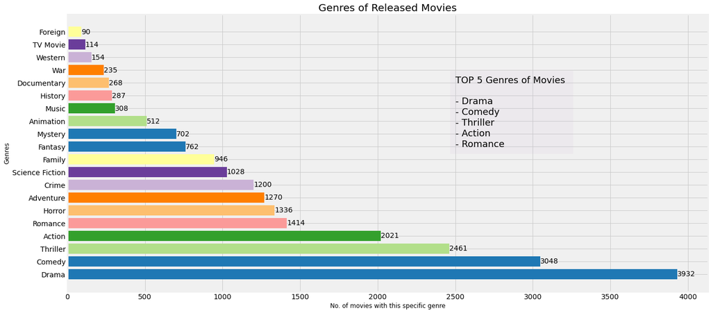

```python
#Set Data
x = genres_series.index
y = genres_series.values

#Ploting one plot and setting the figure size
fig, ax = plt.subplots(figsize=(20, 10))

#get the required color pallete
cmap = mpl.cm.Paired
# adjust range of continious colors
colors = cmap([0.1, 0.12, 0.2, 0.3, 0.4, 0.5, 0.6, 0.7, 0.8, 0.85])

#Plot
ax.barh(x, y, alpha=1, color=colors)

# Label the bars with their corresponding values
ax.bar_label(ax.containers[0], color='black', fontsize=14)
ax.tick_params(axis='x', labelsize=14)
ax.tick_params(axis='y', labelsize=14)

# Let's add some commentary on the plot
ax.text(2500,10,'TOP 5 Genres of Movies \n \n- Drama \n- Comedy \n- Thriller \n- Action \n- Romance', fontsize='18',
        bbox={'facecolor':cmap(0.7), 'alpha': 0.1, 'pad': 10})

#Y-axis name and title
ax.set_xlabel('No. of movies with this specific genre')
ax.set_ylabel('Genres')
ax.set_title ('Genres of Released Movies', fontsize=20);
```

**To better visualize genres and keywords, I created a word cloud function to call it since I'll be using it multiple times for the genres and keywords.**

```python
def cloud_maker(words, w, h, bg_col, wh):
    """
    Creates a word cloud for a given series or frequency list, in this case it's a value counts output

    Args:
        (int) words - pd Series containing the value counts of the words
        (int) w,h - are the width and hieght respectively, don't confuse with figsize
        (str) bg_col - choice of background color
        (str) wh - the number of rows to display i.e. the head of the value counts, it determines how crowded the word cloud will be
    Returns:
        cloud_img - word cloud for the chosen word list and parameters
    """
    plt.figure(figsize=(20,8))
    cloud_img = WordCloud(width=w, height=h, background_color= bg_col).generate_from_frequencies(words.head(wh))
    plt.imshow(cloud_img)
    plt.axis("off")
    return (cloud_img);
```

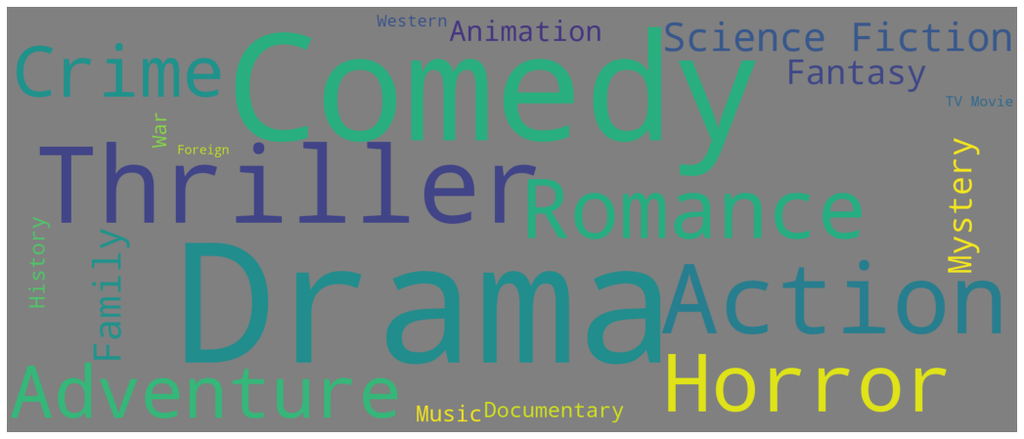

```python
# Let's call the cloud_maker for genres
cloud_maker(genres_series, 1900, 800, 'grey', 20);
```

> - Question 6.1: What are the most keywords used to describe movies?

```python
#Recall the keyword series created in the function previously
keywords_series
```

```
independent film        339
woman director          333
based on novel          271
sex                     263
sport                   200
                       ...
the odyssey               1
beautician                1
attempted kidnapping      1
privileged life           1
half breed                1
Name: value, Length: 7576, dtype: int64
```

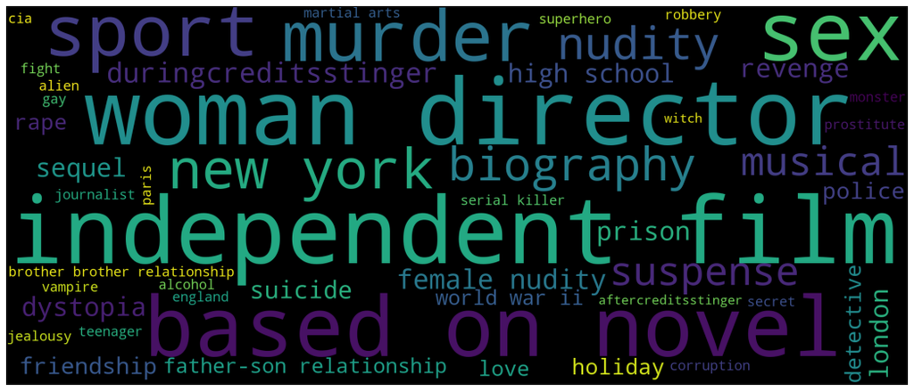

```python
# Recall the cloud_maker for the keyword series
cloud_maker(keywords_series, 1900, 800, 'black', 50);
```

**Question 7: What's the year to recommend to watch the movies released during?**

```python
# First let's check the average popularity rating accross the years
df[['release_year','popularity']].groupby('release_year').mean().sort_values('popularity', ascending=False).head(10)
```

| release_year | popularity |
| --- | --- |
| 2015 | 1.36 |
| 2014 | 1.10 |
| 2004 | 0.86 |
| 2003 | 0.85 |
| 2011 | 0.82 |
| 2001 | 0.81 |
| 2010 | 0.80 |
| 2012 | 0.79 |
| 2013 | 0.79 |
| 2002 | 0.79 |

> **Observation/ Commentary:** According to popularity, the year 2015 seems to be a good year for binging on movies!

```python
# Second let's check the vote_ rating accross the years
df[['release_year','vote_average']].groupby('release_year').agg('mean').sort_values('vote_average', ascending=False).head(10)
```

| release_year | vote_average |
| --- | --- |
| 1973 | 6.70 |
| 1972 | 6.55 |
| 1970 | 6.51 |
| 1971 | 6.49 |
| 1961 | 6.46 |
| 1975 | 6.45 |
| 1974 | 6.40 |
| 1962 | 6.39 |
| 1968 | 6.38 |
| 1976 | 6.38 |

```python
df.groupby(['release_year','original_title'])[['vote_average']].agg('max').sort_values('vote_average', ascending=False).head(10)
```

| release_year | original_title | vote_average |
| --- | --- | --- |
| 2006 | Pink Floyd: Pulse | 8.70 |
| 2011 | The Art of Flight | 8.50 |
| 1981 | Queen - Rock Montreal | 8.50 |
| 2015 | The Jinx: The Life and Deaths of Robert Durst | 8.40 |
| 1994 | The Shawshank Redemption | 8.40 |
| 1984 | Stop Making Sense | 8.40 |
| 2013 | Guten Tag, RamÃ³n | 8.40 |
| 2009 | Iron Maiden: Flight 666 | 8.30 |
| 2008 | Dear Zachary: A Letter to a Son About His Father | 8.30 |
| 2002 | The Century of the Self | 8.30 |

*Question 7.1 Which movies would I recommend watching in the highest averaging year (based on the highest popularity)?*

```python
# Using the df_expanded we'll groupby release_year and original_title to see the movies with the highest popularity and their revenues
df.groupby(['release_year','original_title'])[['popularity']].agg('max').sort_values('popularity', ascending=False).head(10)
```

| release_year | original_title | popularity |
| --- | --- | --- |
| 2015 | Jurassic World | 32.99 |
|  | Mad Max: Fury Road | 28.42 |
| 2014 | Interstellar | 24.95 |
|  | Guardians of the Galaxy | 14.31 |
| 2015 | Insurgent | 13.11 |
| 2014 | Captain America: The Winter Soldier | 12.97 |
| 1977 | Star Wars | 12.04 |
| 2014 | John Wick | 11.42 |
| 2015 | Star Wars: The Force Awakens | 11.17 |
| 2014 | The Hunger Games: Mockingjay - Part 1 | 10.74 |

> **Observation/ Commentary:** We saw earlier that the year 2015 was the highest year in terms of average popularity of movies across the years. So I'd recommend watching these 2 movies of 2015:
> - 2015's Jurassic World with a popularity rating of 32.99
> - 2015's Mad Max: Fury Road with a popularity rating of 28.42

**Question 8: What are the Top 10 highest-revenue movies? By whom were they directed? And what genres do they belong to?**

- Top 10 Highest Revenue Movie Titles/ their directors/ Genres / Revenue

```python
#Grouping the highest revenues movies, finding the max and sorting them
highest_revenue = df.groupby(['original_title','director','genres'])[['revenue_adj']].agg('mean').sort_values('revenue_adj', ascending=False).head(10)
highest_revenue
```

| original_title | director | genres | revenue_adj |
| --- | --- | --- | --- |
| Avatar | James Cameron | Action\|Adventure\|Fantasy\|Science Fiction | 3414034640.00 |
| Star Wars | George Lucas | Adventure\|Action\|Science Fiction | 3368856503.00 |
| Titanic | James Cameron | Drama\|Romance\|Thriller | 3026735566.00 |
| The Exorcist | William Friedkin | Drama\|Horror\|Thriller | 2617261550.00 |
| Jaws | Steven Spielberg | Horror\|Thriller\|Adventure | 2302900254.00 |
| Star Wars: The Force Awakens | J.J. Abrams | Action\|Adventure\|Science Fiction\|Fantasy | 2297728451.00 |
| E.T. the Extra-Terrestrial | Steven Spielberg | Science Fiction\|Adventure\|Family\|Fantasy | 2163650047.00 |
| The Net | Irwin Winkler | Crime\|Drama\|Mystery\|Thriller\|Action | 1911690620.00 |
| One Hundred and One Dalmatians | Clyde Geronimi\|Hamilton Luske\|Wolfgang Reitherman | Adventure\|Animation\|Comedy\|Family | 1901746279.00 |
| The Avengers | Joss Whedon | Science Fiction\|Action\|Adventure | 1742797977.00 |

#### - Let's see how this would look like visually and see how the movie's revenue relate to it's popularity and vote count

```python
# Let's define the bubble labels I'll be using in the chart below
bubble_labels = df_money[:10].sort_values('popularity', ascending=False).original_title
bubble_labels
```

```
0                  Jurassic World
1              Mad Max: Fury Road
2                       Insurgent
3    Star Wars: The Force Awakens
4                       Furious 7
5                    The Revenant
6              Terminator Genisys
7                     The Martian
8                         Minions
9                      Inside Out
Name: original_title, dtype: object
```

[figure not shown]

```python
# create data for scatter_1 (bubbles)
x = df_money[:10].sort_values('popularity', ascending = False).revenue_adj ## NEEDS FIXING
y = df_money[:10].sort_values('popularity', ascending = False).vote_average
z = df_money[:10].sort_values('popularity', ascending = False).popularity
l = bubble_labels

#tweak the size by changing the number at the end
z= z*z*z*1.5

#scatter_2
x1 = df_money.revenue_adj
y1 = df_money.vote_average
z1 = df_money.popularity

fig, ax = plt.subplots(1, figsize=(20, 14))

# Scatter_1 will be for the revenue_adj and vote count and the bubble size will be the populairt
## I chose the top 10 to represent them visually
ax.scatter(x, y, s=z, c=z,cmap="Accent", alpha=0.4, edgecolors="grey", linewidth=1)

#Scatter_2 is for the whole data of revenue_adj vs vote count to show case how the top 10 relate tot he whole data
ax.scatter(x1, y1, s=z1, alpha=0.3, color='blue')

#put the maximum value of vote counts as the limit here
plt.ylim(3, 9)
plt.xlim(0, 3.25e9)

# Add titles (main and on axis)
plt.xlabel("Revenue Adjusted in USD")
plt.ylabel("Movie Vote Average")
plt.title("Revenue Adjusted vs Popularity vs Vote Average", fontsize='22')

# Let's add some commentary on the plot
ax.text(1.5e9,4,'The bubbles present the top 10 most popular movies. \n a big bubble has a high popularity.', fontsize='18',
        bbox={'facecolor':cmap(0.8), 'alpha': 0.1, 'pad': 10})

# Add labels to the bubbles using x,y coordinates and setting the color and fontsize
for i, label in enumerate(l):
    ax.annotate(label, (x[i], y[i]), va='center', ha='center', color="black", fontsize='16')
```

**Question 9: What are the top 10 production companies in terms of movie releases?**

```python
# Let's recall the head of the production company series we created earlier.
prod_comp_series.head(10)
```

```
Warner Bros.                              495
Universal Pictures                        490
Paramount Pictures                        419
Twentieth Century Fox Film Corporation    275
Columbia Pictures                         268
New Line Cinema                           210
Metro-Goldwyn-Mayer (MGM)                 209
Walt Disney Pictures                      191
Touchstone Pictures                       168
Columbia Pictures Corporation             156
Name: value, dtype: int64
```

#### - Let's visualize that info to see how it looks like

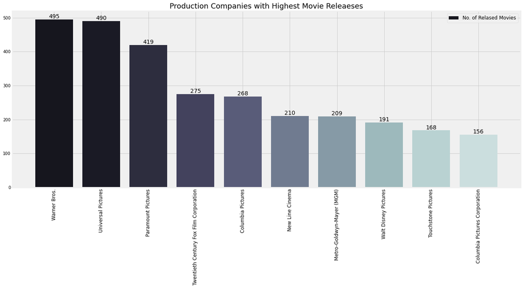

```python
x = prod_comp_series.index[:10]
y = prod_comp_series.values[:10]

#Ploting one plot and setting the figure size
fig, ax = plt.subplots(figsize=(20, 8))

#get the required color pallete
cmap = mpl.cm.bone

# adjust range of continious colors
colors = cmap([0.1, 0.12, 0.2, 0.3, 0.4, 0.5, 0.6, 0.7, 0.8, 0.85])
ax.bar(x, y, alpha=1, color=colors, label='No. of Relased Movies')


# Label the bars with their corresponding values
ax.bar_label(ax.containers[0], color='black', fontsize=14)
ax.tick_params(axis='x', rotation=90, labelsize=12)

#Legend location, size and title
ax.legend(loc='best', fontsize='large')
ax.set_title ('Production Companies with Highest Movie Releaeses', fontsize=18);
```

Reference for the adding labels:https://stackoverflow.com/questions/30228069/how-to-display-the-value-of-the-bar-on-each-bar-with-pyplot-barh

I was looking for a nice visual to use for the top 10 production companies so I thought of a tree map. I searched Google and I came accross a module named Squarify, here are the links for the source: https://github.com/laserson/squarify

I intially found it here as well: https://www.python-graph-gallery.com/treemap/

#### - The Tree Map below will show the share of each company in the Top 10 production companies making movies.

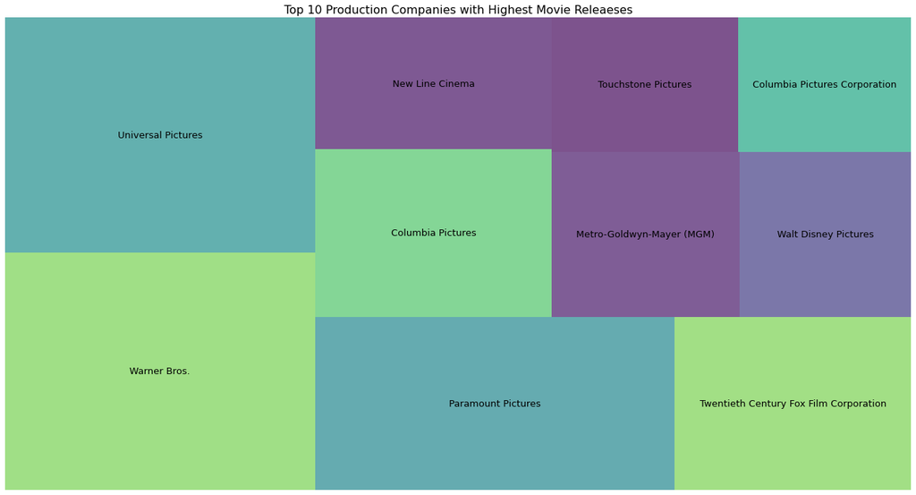

```python
# Setting the data, x will be labels and y will be the values
x = prod_comp_series.index[:10]
y = prod_comp_series.values[:10]

fig, ax = plt.subplots(figsize=(20,12))

#Let's call the squarify module to plot this figure
squarify.plot(sizes=y, label=x, alpha=0.7, text_kwargs={'fontsize':13})
#Turn axis off because ewww
plt.axis('off');

# I'll add a title
ax.set_title ('Top 10 Production Companies with Highest Movie Releaeses', fontsize=16);
```

**Question 10: Who are the top 10 casted actors in the movies?**

```python
# Let's recall the actor's series that we created earlier
actors_series.head(10)
```

```
Robert De Niro       68
Samuel L. Jackson    65
Bruce Willis         61
Nicolas Cage         59
Michael Caine        50
Robin Williams       48
John Goodman         47
Morgan Freeman       47
John Cusack          46
Tom Hanks            46
Name: value, dtype: int64
```

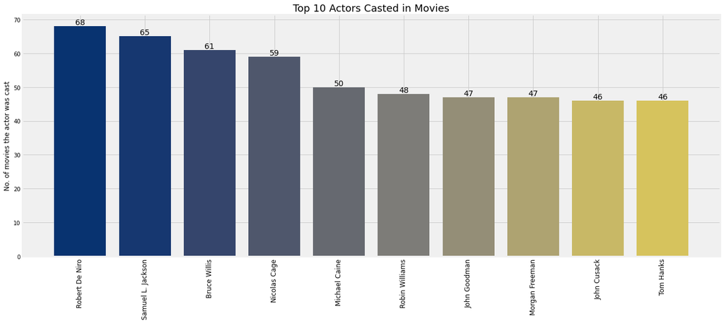

```python
x = actors_series.index[:10]
y = actors_series.values[:10]

#Ploting one plot and setting the figure size
fig, ax = plt.subplots(figsize=(20, 8))

#get the required color pallete
cmap = mpl.cm.cividis

# adjust range of continious colors
colors = cmap([0.1, 0.12, 0.2, 0.3, 0.4, 0.5, 0.6, 0.7, 0.8, 0.85])
ax.bar(x, y, alpha=1, color=colors)


# Label the bars with their corresponding values
ax.bar_label(ax.containers[0], color='black', fontsize=14)
ax.tick_params(axis='x', rotation=90, labelsize=12)
ax.set_ylabel('No. of movies the actor was cast')


#Legend location, size and title
#ax.legend(loc='best', fontsize='large')
ax.set_title ('Top 10 Actors Casted in Movies', fontsize=18);
```

#### - I'll visualize the above result in a form of word cloud, to accopmany the result.

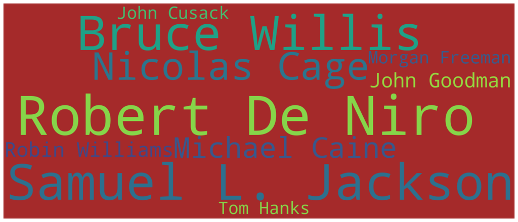

```python
#Let's call on the cloud_maker (feels like I'm calling on Thor :D )
cloud_maker(actors_series, 1900, 800, 'brown', 10);
```

**Question 11: Who are the Top 10 directors with most movie releases?**

```python
# Let's check the list of directors and how many movies they made per year
           #grouping by release year and director checking the original tilte and counting it, then sort and head
#df.groupby(['release_year','director'])['original_title'].agg('count').sort_values(ascending=False).head(5)
directors_series.head(10)
#directors_series
```

```
Woody Allen          41
Clint Eastwood       33
Steven Spielberg     30
Martin Scorsese      27
Ridley Scott         23
Ron Howard           22
Steven Soderbergh    22
Joel Schumacher      20
David Cronenberg     19
Tim Burton           19
Name: value, dtype: int64
```

*Question 11.1: Who were the directors of the higest revenue movies?*

```python
# Let's aggregate to check who were the directors of the highest revenue movies
df.groupby(['director', 'release_year','original_title'])[['revenue_adj']].agg('max').sort_values('revenue_adj', ascending=False).head(10)
```

| director | release_year | original_title | revenue_adj |
| --- | --- | --- | --- |
| James Cameron | 2009 | Avatar | 3414034640 |
| George Lucas | 1977 | Star Wars | 3368856503 |
| James Cameron | 1997 | Titanic | 3026735566 |
| William Friedkin | 1973 | The Exorcist | 2617261550 |
| Steven Spielberg | 1975 | Jaws | 2302900254 |
| J.J. Abrams | 2015 | Star Wars: The Force Awakens | 2297728451 |
| Steven Spielberg | 1982 | E.T. the Extra-Terrestrial | 2163650047 |
| Irwin Winkler | 1995 | The Net | 1911690620 |
| Clyde Geronimi\|Hamilton Luske\|Wolfgang Reitherman | 1961 | One Hundred and One Dalmatians | 1901746279 |
| Joss Whedon | 2012 | The Avengers | 1742797977 |

*Question 11.2: Who were the directors of the most popular movies?*

```python
# Let's aggregate to see who were the directors of the most popular movies
df.groupby(['original_title','director'])[['popularity']].agg('max').sort_values('popularity', ascending=False).head(10)
```

| original_title | director | popularity |
| --- | --- | --- |
| Jurassic World | Colin Trevorrow | 32.99 |
| Mad Max: Fury Road | George Miller | 28.42 |
| Interstellar | Christopher Nolan | 24.95 |
| Guardians of the Galaxy | James Gunn | 14.31 |
| Insurgent | Robert Schwentke | 13.11 |
| Captain America: The Winter Soldier | Joe Russo\|Anthony Russo | 12.97 |
| Star Wars | George Lucas | 12.04 |
| John Wick | Chad Stahelski\|David Leitch | 11.42 |
| Star Wars: The Force Awakens | J.J. Abrams | 11.17 |
| The Hunger Games: Mockingjay - Part 1 | Francis Lawrence | 10.74 |

## Limitations in the Analyzed Dataset

**Limitation 1:** When I did this analysis, I purposely chose to remove the unused columns first thing in the data cleaning process because when I tried to remove them at the end, I ended up with less than 2000 rows of usable data. This is due to the fact that the homepage column has 2936 non-null values, so when I preformed dropping the null values, it removed many of the usable data rows. I'll stick to remove the unused columns first as intially planned. The limitation here being that the dataset has incomplete data, and the question that begs to be answered, is the data realiable to make solid conclusions or not.  
**Limitation 2:** The runtime column had very small values (i.e. 3 mins) and very large ones( i.e. 705 minutes) so I decided to look at the data closely and searched some of the titles with short and long runtime. I noticed that the movies and mini TV series info is mixed in the TMDB csv file meaning there is no way to differenitate between them in the given date, the main clue would be the long runtime, but then again if it's not clearly defined most probably it will be confusing. Additionally, this creates a problem with the analysis output since they are different categories of shows.  
**Limitation 3:** When I checked the revenue_adj and budget_adj columns, there were a lot of zero values. So I checked a random movie Survivor and the budget number is on point but the revenue is zero which is off and it says on the wikipedia page it made in box office $3,839,100 so I'll dropped them. This meant I'm dropped around half of the original values for the df which are due to the zero values in budget_adj and revnue_adj, which might affect my EDA for budgetary and revenue analysis! Again the limitation being there are alot of these values either missing or input incorrectly.  
**Limitation 4:** When I ran the analysis with the main df and dropped the budget and revenue zero values, it changed the release year mode from 2014 to 2011, which might mean that removing all those rows with zero budget and revenue impacted our findings in a big way. This boils down to the data not being reliable enough or inconsistent. One work around is take the release year and original title to make a mini df to get more accurate results or seperate the financial related columns in one as I did in my analysis

[figure not shown]

Image from: https://xkcd.com/552/

## Section 5: References

Reference Name (or URL) (Reference Title)

- https://www.kdnuggets.com/2019/06/select-rows-columns-pandas.html
- https://stackoverflow.com/questions/22649693/drop-rows-with-all-zeros-in-pandas-data-frame
- https://stackoverflow.com/questions/18172851/deleting-dataframe-row-in-pandas-based-on-column-value
- https://towardsdatascience.com/15-ways-to-create-a-pandas-dataframe-754ecc082c17
- https://stackoverflow.com/questions/48590268/pandas-get-the-most-frequent-values-of-a-column
- https://matplotlib.org/stable/api/_as_gen/matplotlib.pyplot.scatter.html#matplotlib.pyplot.scatter
- https://stackoverflow.com/questions/38424459/set-y-axis-limit-in-pandas-histogram
- https://numpy.org/doc/stable/reference/random/generated/numpy.random.uniform.html
- https://towardsdatascience.com/11-examples-to-master-pandas-groupby-function-86e0de574f38
- https://www.datasciencemadesimple.com/reshape-using-stack-unstack-function-pandas-python/
- https://pandas.pydata.org/pandas-docs/stable/user_guide/merging.html</br>
- https://www.geeksforgeeks.org/split-a-text-column-into-two-columns-in-pandas-dataframe/</br>
- https://stackoverflow.com/questions/11346283/renaming-column-names-in-pandas</br>
- https://www.kite.com/python/answers/how-to-append-a-column-from-a-pandas-dataframe-to-another-dataframe-in-python</br>
- https://stackoverflow.com/questions/53227949/count-multiple-values-of-a-dataframe-across-all-columns</br>
- https://towardsdatascience.com/simple-wordcloud-in-python-2ae54a9f58e5</br>
- https://stackoverflow.com/questions/29846087/microsoft-visual-c-14-0-is-required-unable-to-find-vcvarsall-bat</br>
- https://stackoverflow.com/questions/47298070/importerror-no-module-named-wordcloud</br>
- https://github.com/amueller/word_cloud</br>
- https://stackoverflow.com/questions/43606339/generate-word-cloud-from-single-column-pandas-dataframe</br>
- https://www.delftstack.com/howto/matplotlib/how-to-add-title-to-subplots-in-matplotlib/</br>
- https://www.python-graph-gallery.com/341-python-gapminder-animation</br>
- https://matplotlib.org/stable/gallery/style_sheets/ggplot.html</br>
- https://matplotlib.org/stable/tutorials/introductory/customizing.html</br>
- https://matplotlib.org/stable/users/prev_whats_new/dflt_style_changes.html</br>
- https://matplotlib.org/stable/tutorials/colors/colormaps.html
- https://www.python-graph-gallery.com/341-python-gapminder-animation
- http://datacamp-community-prod.s3.amazonaws.com/263130e2-2c92-4348-a356-9ed9b5034247
- https://stackoverflow.com/questions/22725043/convert-dtype-from-int64-to-int32
- https://nfpdiscussions.udacity.com/t/tmdb-movie-dataset-problem-with-cast-and-genres-columns/144587
- https://docs.google.com/presentation/d/1lev5pZEpg8dhEUEr59WOV2heQUJe0_yR/edit#slide=id.p34
- https://stackoverflow.com/questions/41113663/pandas-get-a-list-of-all-data-frames-loaded-into-memory (Dataframes loaded in memory)
- https://matplotlib.org/matplotblog/posts/pyplot-vs-object-oriented-interface/ (OO Plots vs Pyplot)
- https://stackoverflow.com/questions/40207784/how-to-edit-the-label-font-sizes-on-building-a-treemap-with-squarify-in-python (editing label fontsize)
- https://www.geeksforgeeks.org/matplotlib-pyplot-xlim-in-python/ (Setting xlim in plots)
- https://stackoverflow.com/questions/44998205/labeling-points-in-matplotlib-scatterplot (labeling points in scatter plot)
- https://matplotlib.org/stable/gallery/style_sheets/fivethirtyeight.html (538 Style sheet)
- https://matplotlib.org/stable/api/_as_gen/matplotlib.pyplot.annotate.html (Documentation : annotate)
- https://matplotlib.org/stable/tutorials/text/annotations.html#sphx-glr-tutorials-text-annotations-py
- https://matplotlib.org/stable/tutorials/text/text_props.html (Documentation: adding text to plots)
- https://www.tutorialspoint.com/showing-points-coordinates-in-a-plot-in-python-using-matplotlib (Showing points coordinatees)
- https://stackoverflow.com/questions/56231689/how-to-set-the-default-figure-size-and-dpi-of-all-plots-drawn-by-matplotlib-pyp (Setting DPI default parameter)
- https://matplotlib.org/stable/tutorials/colors/colormaps.html (ColorMaps)
- https://matplotlib.org/stable/gallery/color/colormap_reference.html (ColorMaps palletes)
- https://matplotlib.org/stable/gallery/color/named_colors.html (List of name colors)
- Watch this https://www.youtube.com/watch?v=txMdrV1Ut64&ab_channel=CoreySchafer

*I hereby declare I've ethically used all these resources to understand and futher enhance my analysis and visualizations*

```python
# To view and list the saved dataframes in memory
%whos DataFrame
```

```
Variable            Type         Data/Info
------------------------------------------
df                  DataFrame           popularity     bud<...>n[8658 rows x 18 columns]
df_cast             DataFrame                             <...>\n[8658 rows x 5 columns]
df_director         DataFrame                   director_1<...>n[8658 rows x 36 columns]
df_expanded         DataFrame                         orig<...>n[8658 rows x 15 columns]
df_genres           DataFrame              genres_1       <...>\n[8658 rows x 5 columns]
df_keywords         DataFrame               keywords_1  ke<...>\n[8658 rows x 5 columns]
df_money            DataFrame                            o<...>n[3677 rows x 10 columns]
df_movie_runtime    DataFrame           release_year      <...>\n[8641 rows x 3 columns]
df_prod_companies   DataFrame                         prod<...>\n[8658 rows x 5 columns]
highest_revenue     DataFrame                             <...>ure         1742797977.00
```